# Atmospheric Conductance - Sensitivity Analysis

Group L: Genevieve Chiong, Peter Menzies, Alex Clippinger

04/25/2022

# Parts 1-2. Create and Run Atmospheric Conductance Model

The following model is sourced from “compute_atmospheric_conductance.R”.

```r
compute_atmospheric_conductance()
```

```
## $conductance
## [1] 15.44228
```

The model’s single estimate of atmospheric conductance (for a forest that is 10 m high, has wind speeds of 250 cm/s, and a wind speed measurement height (cm) of 200 cm above vegetation) is 15.44228 cm/s.

# Part 3. Sensitivity Analysis

Vegetation height is assumed to be randomly distributed between 9.5 and 10.5 m. The $k_d$ and $k_0$ parameters are assumed to be normally distributed with standard deviation of 1% of their default values. Wind speeds are normally distributed with a mean of 250 cm/s and standard deviation of 30 cm/s.

### a. Use LHS to generate parameter values for the 4 parameters

```r
factors = c("vegetation_ht", "k_d", "k_0", "wind_speed")

nsets = 100

q = c("qunif", # vegetation height randomly distributed
      "qnorm", # k_d normally distributed
      "qnorm",
      "qnorm"
      )

q.arg = list(list(min = 950, max = 1050), # vegetation height
             list(mean = 0.7, sd = 0.7*0.01),
             list(mean = 0.1, sd = 0.1*0.01),
             list(mean = 250, sd = 30))

set.seed(1001)
sens_conductance = LHS(NULL, factors, nsets, q, q.arg)
sens_pars = get.data(sens_conductance)
head(sens_pars)
```

```
##   vegetation_ht       k_d        k_0 wind_speed
## 1        1036.5 0.6956040 0.09934116   265.3022
## 2         984.5 0.6979534 0.10008784   315.1027
## 3        1028.5 0.7091741 0.10085962   264.4518
## 4         997.5 0.6951678 0.10217009   191.2011
## 5        1020.5 0.7015029 0.10031864   231.1598
## 6         965.5 0.6925931 0.10101522   229.2907
```

### b. Run atmospheric conductance model for these parameter sets

```r
conductances = sens_pars %>% pmap(compute_atmospheric_conductance)

conductances_df = conductances %>% map_dfr(`[`, c("conductance"))

sens_conductance = pse::tell(sens_conductance, t(as.matrix(conductances_df)),
                             res.names = c("conductance"))
```

### c. Plot conductance estimates accounting for parameter uncertainty

Conductance estimates, accounting for parameter uncertainty, are displayed using a boxplot and histogram below.

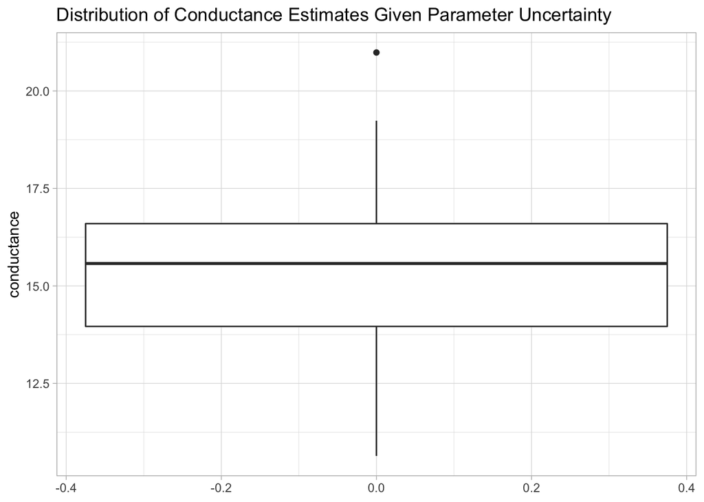

```r
ggplot(conductances_df, aes(y=conductance)) +
  geom_boxplot() +
  theme_light() +
  labs(title = "Distribution of Conductance Estimates Given Parameter Uncertainty")
```

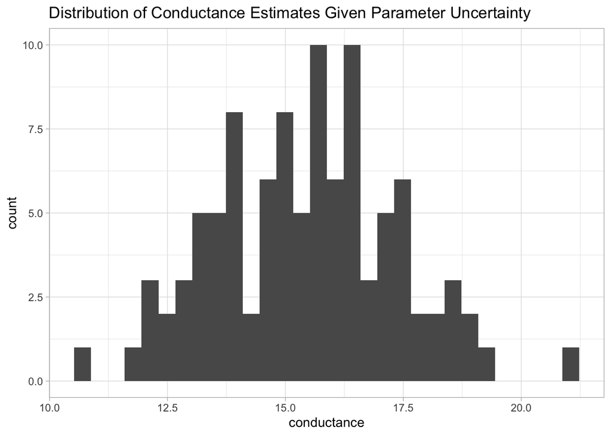

```r
ggplot(conductances_df, aes(conductance)) +
  geom_histogram() +
  theme_light() +
  labs(title = "Distribution of Conductance Estimates Given Parameter Uncertainty")
```

### d. Plot conductance estimates against each parameter

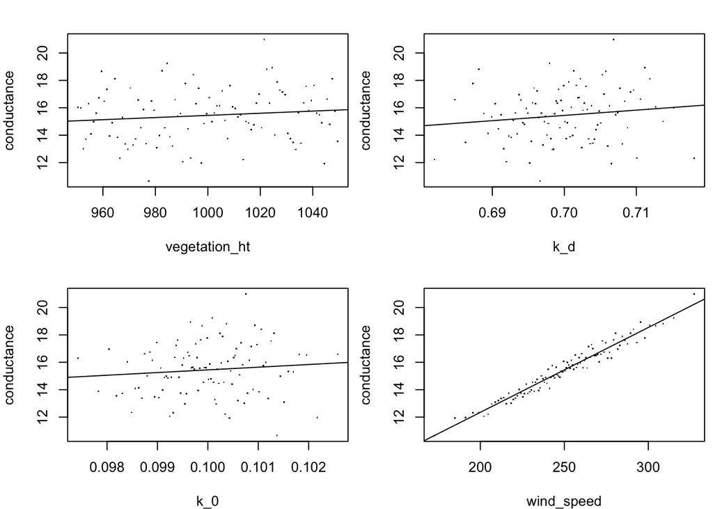

```r
pse::plotscatter(sens_conductance)
```

The plots above indicate that there is a stronger relationship between wind speed uncertainty and conductance than that of the other three parameters.

### e. Estimate the Partial Rank Correlation Coefficients (PRCC)

The PRCC values are plotted and displayed below.

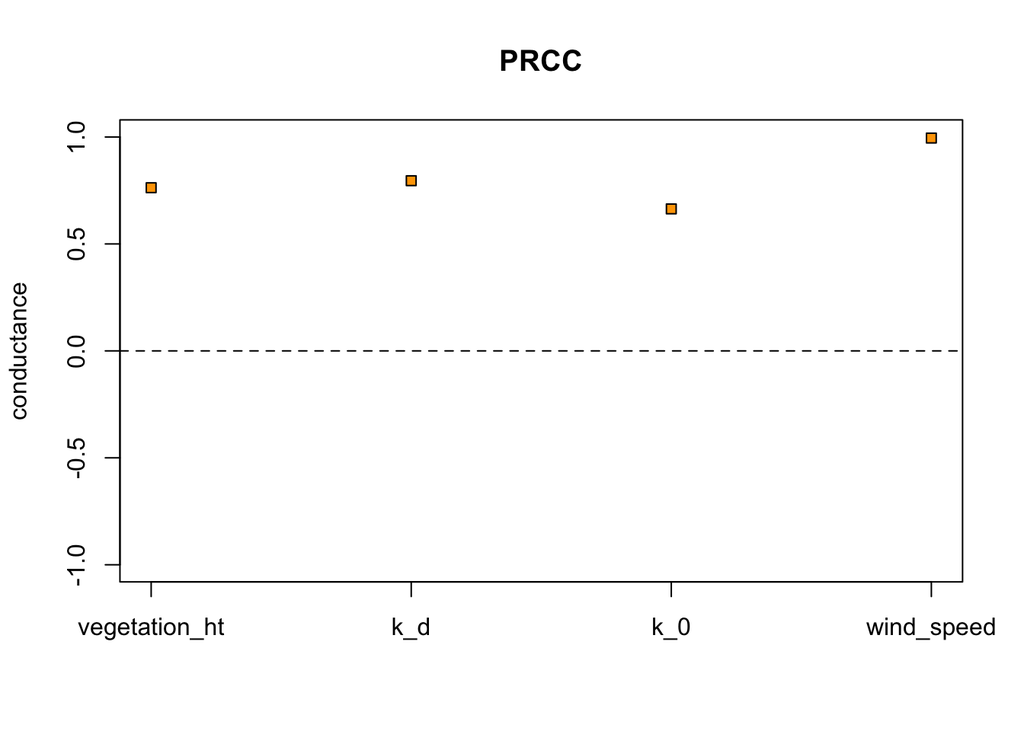

```r
pse::plotprcc(sens_conductance)
```

```r
sens_conductance$prcc
```

```
## [[1]]
##
## Call:
## pcc.default(X = L, y = r, rank = T, nboot = nboot)
##
## Partial Rank Correlation Coefficients (PRCC):
##                original
## vegetation_ht 0.7628966
## k_d           0.7956632
## k_0           0.6638527
## wind_speed    0.9950506
```

Additionally, Spearman correlation for these four values are given below.

```r
veg_cor = cor(conductances_df$conductance, sens_pars$vegetation_ht, method = "spearman")
kd_cor = cor(conductances_df$conductance, sens_pars$k_d, method = "spearman")
k0_cor = cor(conductances_df$conductance, sens_pars$k_0, method = "spearman")
windspd_cor = cor(conductances_df$conductance, sens_pars$wind_speed, method = "spearman")

parameters = c("Vegetation Height", "k_d", "k_0", "Wind Speed")
cors = c(veg_cor, kd_cor, k0_cor, windspd_cor)

tibble("Parameter" = parameters,
       "Correlation" = cors)
```

```
## # A tibble: 4 × 2
##   Parameter         Correlation
##   <chr>                   <dbl>
## 1 Vegetation Height       0.118
## 2 k_d                     0.154
## 3 k_0                     0.123
## 4 Wind Speed              0.975
```

### f. Discussion of Results

The results of our sensitivity analysis indicate that atmospheric conductance estimated by our model is most sensitive to uncertainty in wind speed. The other parameters - vegetation height, $k_0$, and $k_d$, are less impactful given uncertainty. This suggests that in order to reduce uncertainty in aerodynamic conductance estimates, the most important parameter to control for is wind speed.

Research has shown that global wind speeds have been decreasing for several decades since the 1970s, before picking up in 2010. In a study published in Nature Climate Change in 2019, researchers found that big climate patterns have a major influence of wind speeds and that winds across much of North America, Europe and Asia have been growing faster since about 2010. Given this, climate change may exacerbate plant water use sensitivity if warmer climate results in more volatile and uncertain wind speeds.

**Citations**

IPCC, 2021: Climate Change 2021: The Physical Science Basis. Contribution of Working Group I to the Sixth Assessment Report of the Intergovernmental Panel on Climate Change [Masson-Delmotte, V., P. Zhai, A. Pirani, S.L.Connors, C. Péan, S. Berger, N. Caud, Y. Chen, L. Goldfarb, M.I. Gomis, M. Huang, K. Leitzell, E. Lonnoy, J.B.R. Matthews, T.K. Maycock, T. Waterfield, O. Yelekçi, R. Yu, and B. Zhou (eds.)]. Cambridge University Press. In Press.

Zeng, Z., Ziegler, A.D., Searchinger, T. et al. A reversal in global terrestrial stilling and its implications for wind energy production. Nat. Clim. Chang. 9, 979–985 (2019). https://doi.org/10.1038/s41558-019-0622-6